This tutorial is developed based on https://www.gw-openscience.org/s/events/GW150914/GW150914_tutorial.html and the one built by Professor PH.

# Preparation

- Download data at </br>

https://www.dropbox.com/sh/w08qw2v42azxuy6/AABse9Ebiu9fZI6QJ7eg3t3Ha?dl=0

- Load libraries

```python
# Standard python numerical analysis imports:
import numpy as np
import math
from scipy import signal
from scipy.interpolate import interp1d
from scipy.signal import butter, filtfilt, iirdesign, zpk2tf, freqz

import matplotlib.pyplot as plt
import matplotlib.mlab as mlab
import h5py

# LIGO-specific readligo.py
import readligo as rl
```

- Load LIGO data from H1

Here we use H1 data as an example

```python
fn = 'data/H-H1_LOSC_4_V1-1126259446-32.hdf5'
strain, sampletimes, chan_dict = rl.loaddata(fn, 'H1')
```

# First look at data

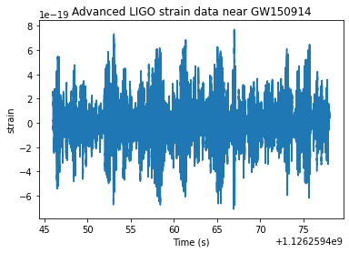

```python
#----------------------------------------------------------------
# Show LIGO strain vs. time
#----------------------------------------------------------------

plt.figure()
plt.plot(sampletimes, strain)
plt.xlabel('Time (s)')
plt.ylabel('strain')
plt.title('Advanced LIGO strain data near GW150914')
plt.savefig('plots/GW150914_strain.png')
```

The data are dominated by low frequency noise; there is no way to see a signal here, without some signal processing. These low frequency oscillations are essentially ignored in LIGO data analysis (see bandpassing, below). We will be "whitening" the data, below.

# Power Spectrum Density

Ref: https://en.wikipedia.org/wiki/Spectral_density#Power_spectral_density

Plotting these data in the Fourier domain gives us an idea of the frequency content of the data.

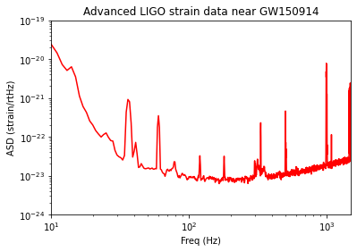

```python
#----------------------------------------------------------------
# Obtain the power spectrum density PSD / ASD
#----------------------------------------------------------------

psdx, psdfreqs = mlab.psd(strain, Fs = 4096, NFFT = 4096)
psd = interp1d(psdfreqs, psdx)

plt.figure()
plt.loglog(psdfreqs, np.sqrt(psdx),'r',label='H1 strain')
plt.axis([10, 1500, 1e-24, 1e-19])
plt.ylabel('ASD (strain/rtHz)')
plt.xlabel('Freq (Hz)')
plt.title('Advanced LIGO strain data near GW150914')
plt.savefig('plots/GW150914_ASDs.png')
```

We can't see the signal in this plot, since it is relatively weak and less than a second long, while this plot averages over 32 seconds of data. So this plot is entirely dominated by instrumental noise.

# Whitening data

From the ASD above, we can see that noise fluctuations are much larger at low and high frequencies and near spectral lines. We can "whiten" the data, suppressing the extra noise at low frequencies and at the spectral lines, to better see the weak signals in the most sensitive band.

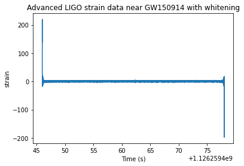

```python
#----------------------------------------------------------------
# Whitening data
#----------------------------------------------------------------

def whiten(strain, interp_psd, dt):
    Nt = len(strain)
    freqs = np.fft.rfftfreq(Nt, dt)
    hf = np.fft.rfft(strain)
    white_hf = hf / (np.sqrt(interp_psd(freqs) /dt/2.))
    white_ht = np.fft.irfft(white_hf, n=Nt)
    return white_ht

white_data = whiten(strain, psd, sampletimes[1]-sampletimes[0])

plt.figure()
plt.plot(sampletimes, white_data)
plt.xlabel('Time (s)')
plt.ylabel('strain')
plt.title('Advanced LIGO strain data near GW150914 with whitening')
plt.savefig('plots/GW150914_strain_whiten.png')
```

# Bandpassing filter

To get rid of remaining high frequency noise, we will also bandpass the data. The macro below shows you a framework to do bandpanssing, but you need to find proper frequency windows by yourself.

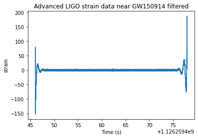

```python
#----------------------------------------------------------------
# Bandpass filtering
#----------------------------------------------------------------
# You need to tune this filter frequencies by yourself
freq_low = 1
freq_high = 2000.
bb, ab = butter(4, [freq_low*2./4096, freq_high*2./4096], btype='band')
white_data_bp = filtfilt(bb, ab, white_data)

plt.figure()
plt.plot(sampletimes, white_data_bp)
plt.xlabel('Time (s)')
plt.ylabel('strain')
plt.title('Advanced LIGO strain data near GW150914 filtered')
plt.savefig('plots/GW150914_strain_whiten_filter.png')
```

# Analytic model (under construction)

Combining knowledge of a little bit of GR and 8.01 physics, we can get the radiation power from this system \begin{eqnarray} \frac{dE_{tot}}{dt} & = & -\frac{2}{3}\left(\frac{G^2 M^5_{c}}{32\omega}\right)^{\frac{1}{3}}\dot{\omega}\\ \end{eqnarray} and the oscilliation frequency as a function of time $t$ \begin{eqnarray} \omega(t) & = & 2\pi\left(134\rm{Hz}\right)\left(\frac{1.21 M_{\odot}}{M_{c}}\right)^{\frac{5}{8}}\left(\frac{1\rm{s}}{\Delta t}\right)^{\frac{3}{8}} \end{eqnarray} Let's take a look at how it looks like.

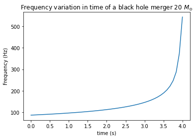

```python
#----------------------------------------------------------------
# Frequency analytic
#----------------------------------------------------------------

def gwfreq(iM,iT,iT0):
    const = (134.*np.pi*2)*np.power((1.21/iM),5./8.)
    output = const*np.power(np.maximum((iT0-iT),3e-2),-3./8.) # we can max it out above 500 Hz-ish
    return output

times = np.linspace(0., 4., 50)
freq = gwfreq(20, times, 4)
plt.figure()
plt.plot(times, freq)
plt.xlabel('time (s)')
plt.ylabel('Frequency (Hz)')
plt.title('Frequency variation in time of a black hole merger 20 $M_{\odot}$')
plt.savefig('plots/GW150914_spectrogram_analytic.png')
```

# Spectrograms

Now let's look back to our data. To compare to the analytic model built above, we present our data with a time-frequency spectrogram.

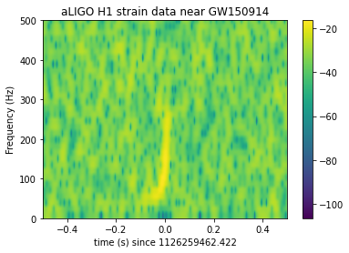

```python
#----------------------------------------------------------------
# Spectrogram
#----------------------------------------------------------------

tevent = 1126259462.422         # Mon Sep 14 09:50:45 GMT 2015
indxt = np.where((sampletimes >= tevent-10) & (sampletimes < tevent+10))
NFFT = 4096/16
NOVL = NFFT*15/16
window = np.blackman(NFFT)
spec_cmap='viridis'

plt.figure()
spec_H1, freqs, bins, im = plt.specgram(white_data[indxt], NFFT=NFFT, Fs=4096, window=window,
                                        noverlap=NOVL, cmap=spec_cmap, xextent=[-10,10])
plt.xlabel('time (s) since '+str(tevent))
plt.ylabel('Frequency (Hz)')
plt.colorbar()
plt.axis([-0.5, 0.5, 0, 500])
plt.title('aLIGO H1 strain data near GW150914')
plt.savefig('plots/GW150914_spectrogram_whitened.png')
```

The yellow line is our signal! Next we look at radiation.

# Analytic model - Wave form

By comibining the radiation power and frequency obtained above, we can get a wave form function \begin{eqnarray} f(t) = A(t)\cos(\omega(t)t+\phi) \end{eqnarray} For the amplitude variation, we can use the power output. Try to come up with a proper $A(t)$ using radiation power output. I have one answer in my mind, which leads to the shape below.

[figure not shown]

Now let's see if it's similar with our data. We zoom in the plot 'Advanced LIGO strain data near GW150914 filtered'.

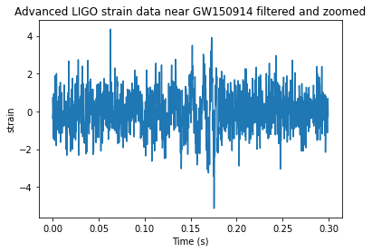

```python
#----------------------------------------------------------------
# Zoom and fit
#----------------------------------------------------------------

indxt = np.where((sampletimes >= tevent-0.17) & (sampletimes < tevent+0.13))
x = sampletimes[indxt]
x = x-x[0]
white_data_zoom = white_data[indxt]
white_data_zoom_bp = white_data_bp[indxt]

plt.figure()
plt.plot(x, white_data_zoom_bp)
plt.xlabel('Time (s)')
plt.ylabel('strain')
plt.title('Advanced LIGO strain data near GW150914 filtered and zoomed')
plt.savefig('plots/GW150914_strain_whiten_filter_zoom.png')
```

We don't see the oscillation shape because the data is not properly filtered. If you apply a good bandpassing, we will obtain the plot below. Then using the wave form function to fit this distribution, you will get an estimation of the black hole mass.

[figure not shown]

To get the actual form you need to do complicated numerical simulations. As a next step for this project, you can load the template databse and try to tune this function to get the parameters (see template notebook). There are also a number of parameters you can tweak here as well.

# Scan long time range

When we zoom in the data above, we look at the small range where the signal is. However in reality we don't know where the signal is in advance, so you need to develop your machinery to search for GW events across a long time range. You can fit one short range by one and see the significance. There is one example below

[figure not shown]

In this figure we can easily find the signal.

# More things to explore

Additionally, you should pull the Livingston and Virgo data and try to see if you can align the different waveforms. Do you see a good coincidence. How do you quantify. Given the alignment what direction are the GWs coming from? Also, you can pull in the official wave forms and try to tune your model. Additionally, it would be nice to know how far the GW occured? How would you compute the distance? What about the other GW events? What parameters do you see? In particular, what does then neutron star merger look like?